# Final Project–Predict Opioid Overdose Events in Cincinnati

#### 3.3.2. A small multiple scatterplot with correlations

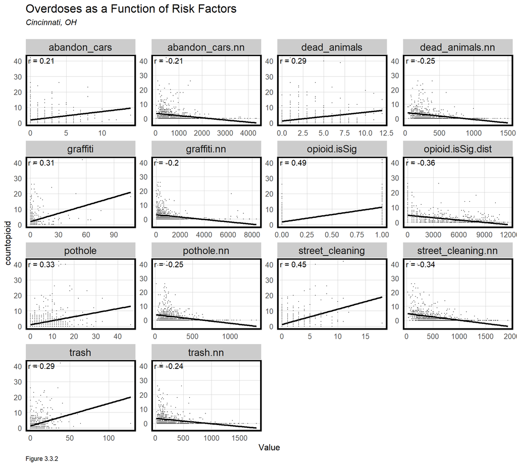

```r
# A small multiple scatterplot with correlations
cin.correlation.long <-
  st_drop_geometry(cin_final_net) %>%
    dplyr::select(-uniqueID, -cvID, -NEIGH, -DISTRICT) %>%
    gather(Variable, Value, -countopioid)

cin.correlation.cor <-
  cin.correlation.long %>%
  group_by(Variable) %>%
  summarize(cin.correlation = cor(Value, countopioid, use = "complete.obs"))
ggplot(cin.correlation.long, aes(Value, countopioid)) +
  geom_point(size = 0.1) +
  geom_text(data = cin.correlation.cor, aes(label = paste("r =", round(cin.correlation, 2))),
            x=-Inf, y=Inf, vjust = 1.5, hjust = -.1) +
  geom_smooth(method = "lm", se = FALSE, colour = "black") +
  facet_wrap(~Variable, ncol = 4, scales = "free") +
  labs(title = "Overdoses as a Function of Risk Factors",
       subtitle = "Cincinnati, OH\n",
       caption = "Figure 3.3.2")+
  plotTheme()
```

#### 3.3.3 A histogram of dependent variable

Since overdose events are relatively uncommon, it is reasonable that most grid cells do not contain events. According to the following bar chart, OLS regression is not appropriate and the distribution of dependent variables is poisson distribution, indicating that Poisson model should be considered when establishing the model.

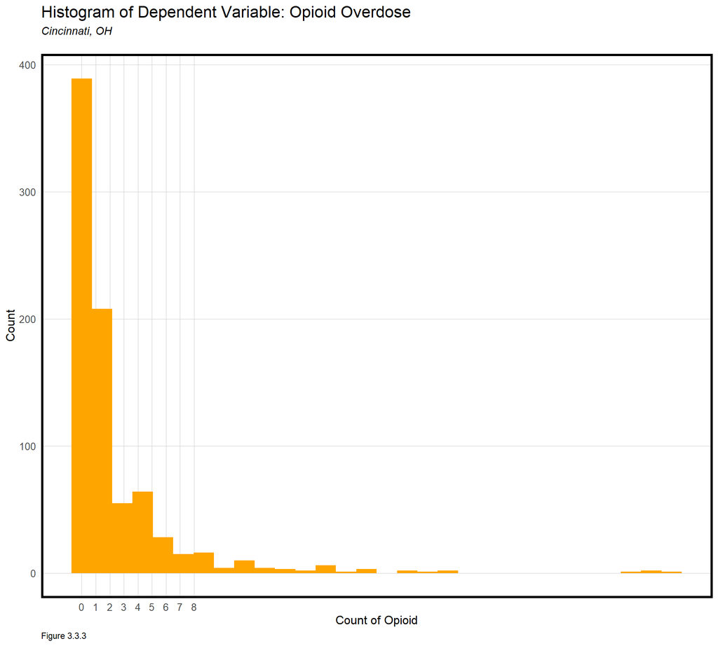

```r
# A histogram of dependent variable
ggplot(data = cin_final_net) +
  geom_histogram(aes(x = countopioid), fill = 'orange') +
  scale_x_continuous(breaks = seq(0, 8, by = 1)) +
  labs(title="Histogram of Dependent Variable: Opioid Overdose",
       subtitle = "Cincinnati, OH\n",
       caption = "Figure 3.3.3") +
  xlab('Count of Opioid') +
  ylab('Count') +
  plotTheme()
```

## IV. Regression Model Building and Accuracy, Generalzability

### 4.1 A small multiple map of model errors by random k-fold and spatial cross validation.

For a given risk factor, we selected the feature count in each fishnet, the distance to the hotspot of overdose event and the distance to the hotspot of important overdose as the features used in the model to avoid collinearity. We also added the local Moran’s I spatial process feature.

The fit index is generated for four regressions, two of which include * just risk factors * (“rega. Vars”), and the second (“rega. SS. Vars”) includes risk factors plus the created local Moran’s I spatial process feature. The best way to test for this is to hold out one local area, train the model on the remaining n - 1 areas, predict for the hold out, and record the goodness of fit, which is the cross-validation approach called LEAVE ONE GROUP OUT (LOGO-CV) used in the analysis. `reg.ss.cv` performs random k-fold cross validation using spatial process features, while `reg.ss.spatialCV` performs LOGO-CV, spatial cross-validation on neighborhood name, using the same features. Same processes are also conducted on *Just Risk Factors*.

### 4.2 Model errors by random k-fold and spatial cross validation

#### 4.2.1 Distribution of MAE

Figure 4.2.1 below displays the distribution of MAE across all models. Some small errors clustering can be captured, indicating the models perform well in terms of generalizability across the city.

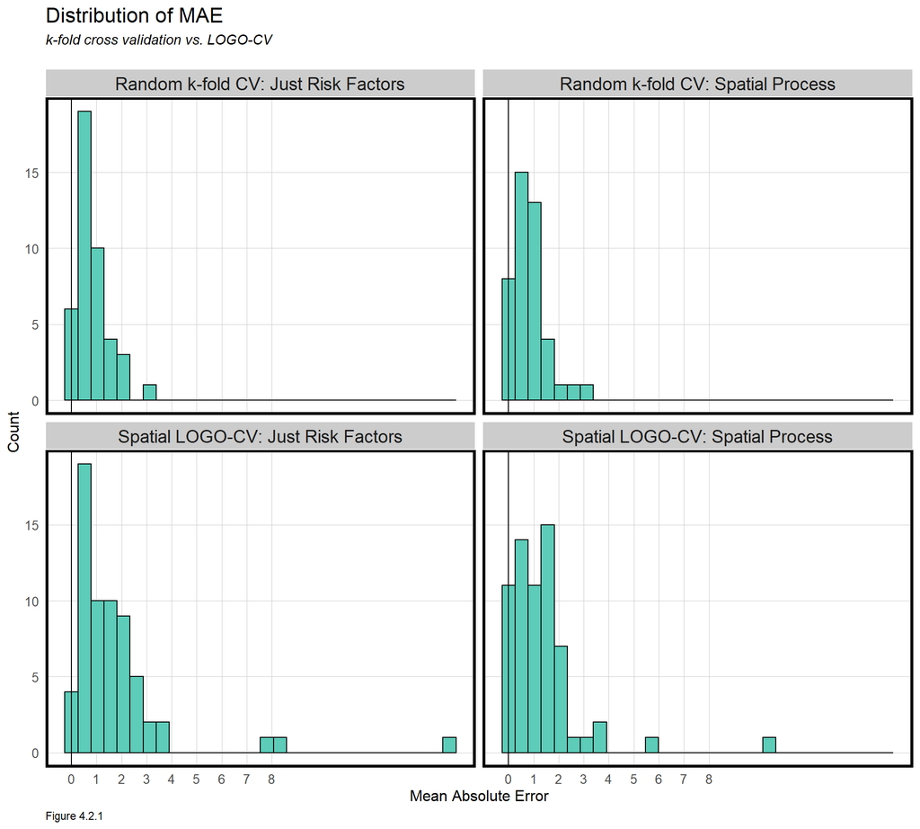

```r
## Distribution of MAE
error_by_reg_and_fold %>%
  ggplot(aes(MAE)) +
  geom_histogram(bins = 30, colour="black", fill = "#5dccb9") +
  facet_wrap(~Regression) +
  geom_vline(xintercept = 0) +
  scale_x_continuous(breaks = seq(0, 8, by = 1)) +
  labs(title="Distribution of MAE",
       subtitle = "k-fold cross validation vs. LOGO-CV\n",
       caption = "Figure 4.2.1",
       x="Mean Absolute Error", y="Count") +
  plotTheme()
```

#### 4.2.2 Visualizes the random k-fold and LOGO-CV errors spatially.

Figure 4.2.2 provides additional information on the errors across models. The largest errors are in the hotspot locations.

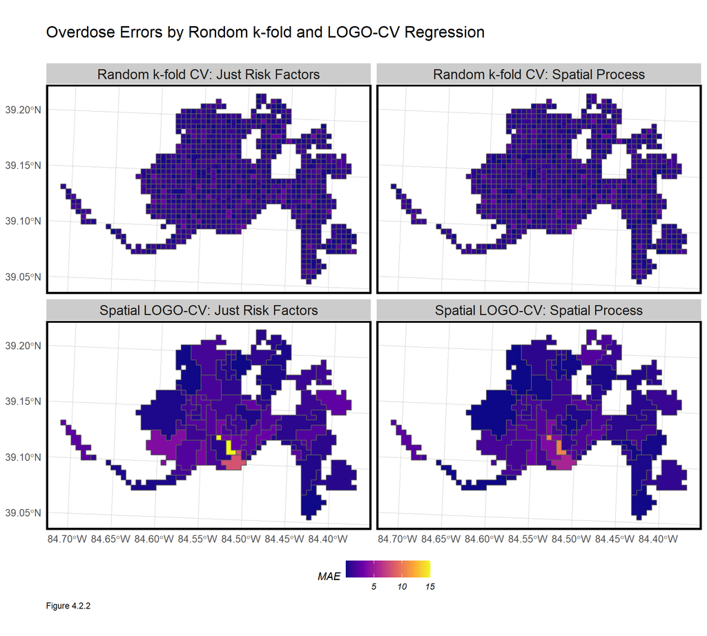

```r
error_by_reg_and_fold %>%
  ggplot() +
  geom_sf(aes(fill = MAE)) +
  facet_wrap(~Regression) +
  scale_fill_viridis_c(option = "plasma") +
  labs(title = "Overdose Errors by Rondom k-fold and LOGO-CV Regression\n",
       caption = 'Figure 4.2.2') +
  mapTheme() +
  theme(legend.position="bottom") +
  plotTheme()
```

### 4.3 Predicted overdose and observed overdose

Interestingly, Figure 4.3 below shows that all models over-predict in low overdose-rate areas and under-predict in hot spot areas. Over-predictions in lower overdose areas may highlight areas of latent risk. Under-prediction in higher overdose areas may reflect difficulty predicting the hotspots.

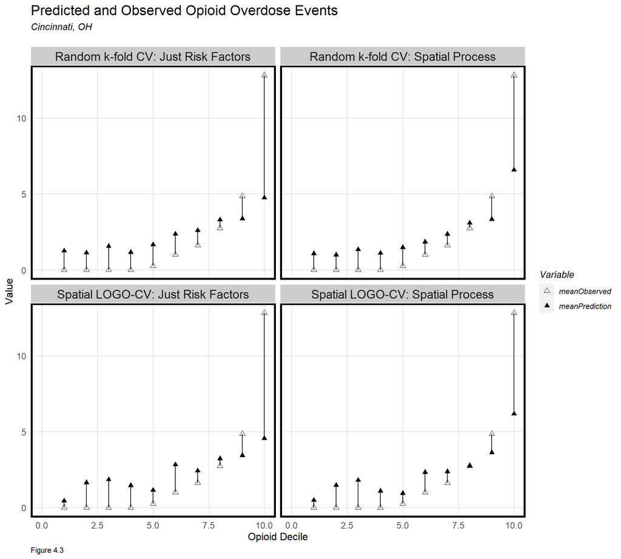

```r
st_drop_geometry(reg.summary) %>%
  group_by(Regression) %>%
  mutate(opioid_Decile = ntile(countopioid, 10)) %>%
  group_by(Regression, opioid_Decile) %>%
  summarize(meanObserved = mean(countopioid, na.rm=T),
            meanPrediction = mean(Prediction, na.rm=T)) %>%
  gather(Variable, Value, -Regression, -opioid_Decile) %>%
  ggplot(aes(opioid_Decile, Value, shape = Variable)) +
  geom_point(size = 2) +
  geom_path(aes(group = opioid_Decile), colour = "black") +
  scale_shape_manual(values = c(2, 17)) +
  facet_wrap(~Regression) + xlim(0,10) +
  labs(title = "Predicted and Observed Opioid Overdose Events",
       subtitle = "Cincinnati, OH\n",
       caption = "Figure 4.3",
       x = 'Opioid Decile') +
  plotTheme()
```

### 4.4 A table of MAE and standard deviation MAE by regression.

```r
st_drop_geometry(error_by_reg_and_fold) %>%
  group_by(Regression) %>%
    summarize(Mean_MAE = round(mean(MAE), 2),
              SD_MAE = round(sd(MAE), 2)) %>%
  kable() %>%
    kable_styling("striped", full_width = F) %>%
    row_spec(2, color = "black", background = "#FDE725FF") %>%
    row_spec(4, color = "black", background = "#FDE725FF")
```

| Regression | Mean_MAE | SD_MAE |
| --- | --- | --- |
| Random k-fold CV: Just Risk Factors | 0.83 | 0.65 |
| Random k-fold CV: Spatial Process | 0.83 | 0.64 |
| Spatial LOGO-CV: Just Risk Factors | 1.77 | 2.24 |
| Spatial LOGO-CV: Spatial Process | 1.36 | 1.54 |

### 4.5 Generalizability by neighborhood context

To test whether the algorithm can be generalized in different neighborhood contexts, TidyCensus is used to pull data through census areas. MedHHInc is calculated and the slices are divided into two groups, High_Income and Low_Income. Spatial subsets are used to obtain regions within the study area.

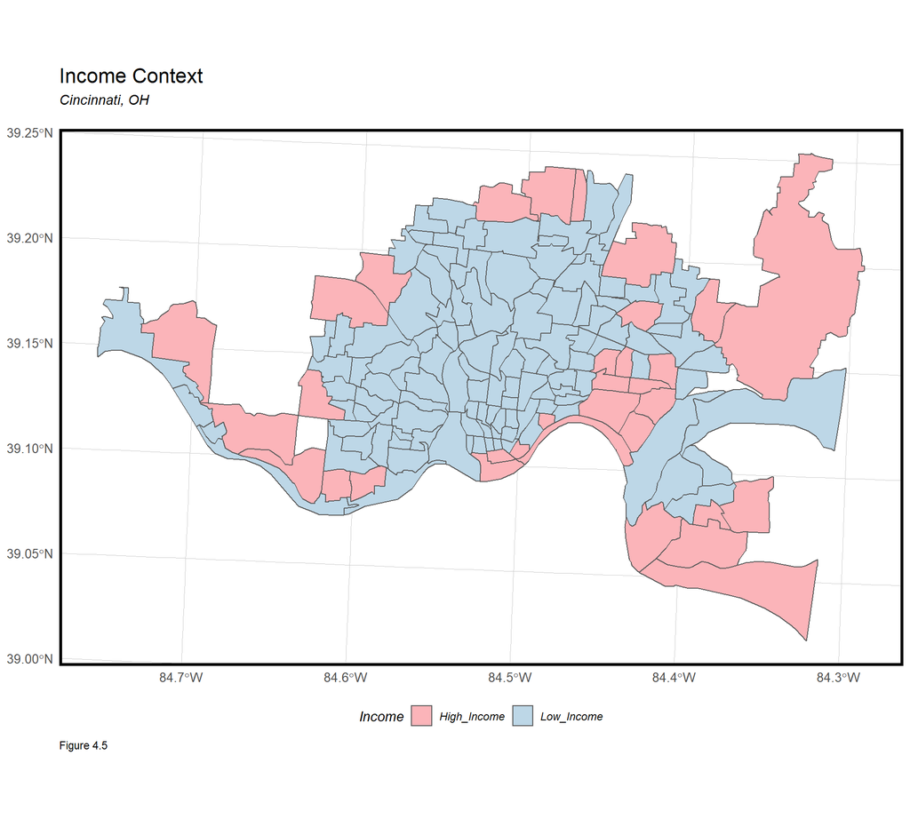

```r
## Fetch census data
# View(load_variables(2017,'acs5',cache = TRUE))
#variable19 <- load_variables(2017, "acs5", cache = TRUE)

tracts17<-
  get_acs(geography = "tract",variables = c("B01001_001E","B02001_002E","B19013_001E"),
          year=2017, state="OH", county="Hamilton", geometry=T, output="wide") %>%
  st_transform('ESRI:102258') %>%
  rename(TotalPop = B01001_001E,
         Whites = B02001_002E,
         MedHHInc = B19013_001E) %>%
  mutate(percentWhite = Whites / TotalPop,
         raceContext = ifelse(percentWhite > .5, "Majority_White", "Majority_Non_White"),
         Income = ifelse(MedHHInc > 60000, "High_Income", "Low_Income")) %>%
  .[cinNeigh,]

ggplot() +
  geom_sf(data = na.omit(tracts17), aes(fill = Income)) +
  scale_fill_manual(values = c("#fbb4b9", "#bdd7e7"), name="Income") +
  labs(title = "Income Context",
       subtitle = "Cincinnati, OH\n",
       caption = 'Figure 4.5') +
  mapTheme() +
  theme(legend.position="bottom") +
  plotTheme()
```

#### 4.5.2 A Table of Mean Error by Neighborhood Income Context

A positive difference represents an over-prediction. The model over-predict risk in higher-income areas and under predict risk in lower-income areas. If reporting selection bias is a problem, then this model may unfairly and disproportionately distribute resources within the community.

```r
reg.summary %>%
  filter(str_detect(Regression, "LOGO")) %>%
  st_centroid() %>%
  st_join(tracts17) %>%
  na.omit() %>%
  st_drop_geometry() %>%
  group_by(Regression, Income) %>%
  summarize(mean.Error = mean(Error, na.rm = T)) %>%
  spread(Income, mean.Error) %>%
  kable(caption = "Table 4.5 Mean Error by Neighborhood Income Context") %>%
  kable_styling("striped", full_width = F)
```

Table 4.5 Mean Error by Neighborhood Income Context

| Regression | High_Income | Low_Income |
| --- | --- | --- |
| Spatial LOGO-CV: Just Risk Factors | 0.2434637 | -0.0704255 |
| Spatial LOGO-CV: Spatial Process | 0.1465042 | -0.0514139 |

### 4.6 Model Alternative and Comparison

#### 4.6.1 The Map Comparing Kernel Density to Risk Predictions

In this section, this analysis is aimed at figuring out if the predictive policing model is able to better predict opioid overdose incidents compared with traditional model - **Kernel Density Model**.

By making kernel density maps with different search radius scale (1000 Ft, 1500 Ft, and 2000 Ft), this analysis select the one with 1000 Ft search radius since it can better display the density of overdose cases.

Next, a comparison map is generated of the risk categories for both model types with a sample of overdose cases in 2017 points overlaid. A well fit model should show that the risk predictions capture a greater share of 2017 opioid events in the highest risk category relative to the Kernel density.

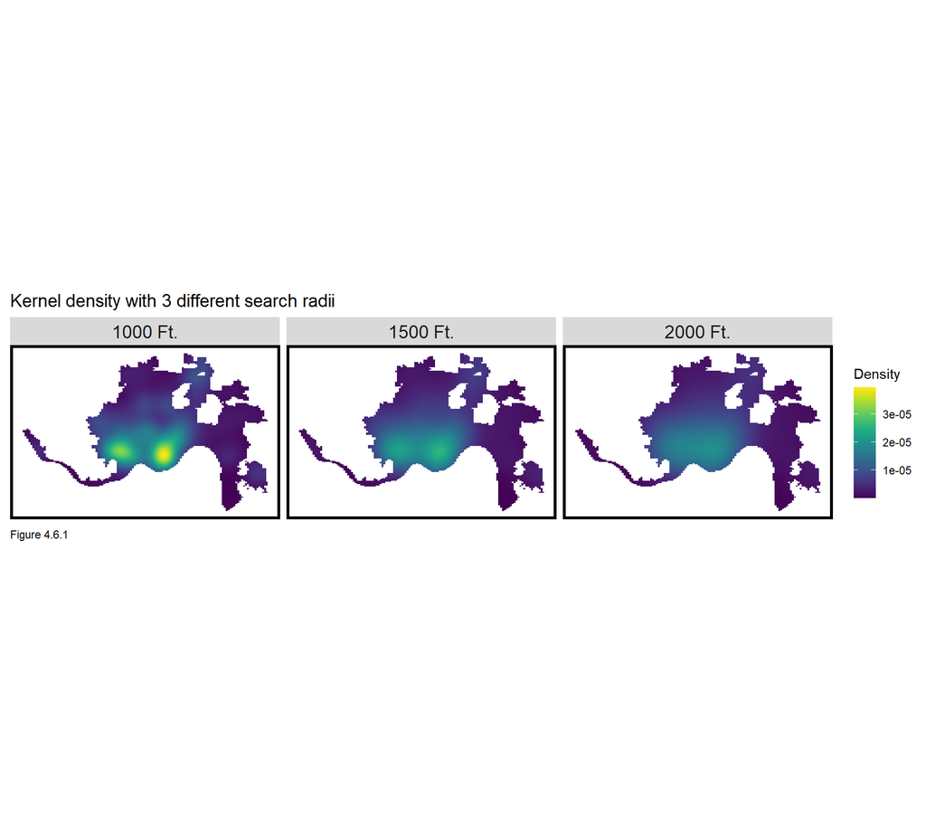

```r
### Make Kernel Density Map
burg_ppp <- as.ppp(st_coordinates(opioid), W = st_bbox(cin_final_net))
burg_KD.1000 <- spatstat.core::density.ppp(burg_ppp, 1000)
burg_KD.1500 <- spatstat.core::density.ppp(burg_ppp, 1500)
burg_KD.2000 <- spatstat.core::density.ppp(burg_ppp, 2000)
burg_KD.df <- rbind(
  mutate(data.frame(rasterToPoints(mask(raster(burg_KD.1000), as(cinNeigh, 'Spatial')))), Legend = "1000 Ft."),
  mutate(data.frame(rasterToPoints(mask(raster(burg_KD.1500), as(cinNeigh, 'Spatial')))), Legend = "1500 Ft."),
  mutate(data.frame(rasterToPoints(mask(raster(burg_KD.2000), as(cinNeigh, 'Spatial')))), Legend = "2000 Ft."))

burg_KD.df$Legend <- factor(burg_KD.df$Legend, levels = c("1000 Ft.", "1500 Ft.", "2000 Ft."))

ggplot(data=burg_KD.df, aes(x=x, y=y)) +
  geom_raster(aes(fill=layer)) +
  facet_wrap(~Legend) +
  coord_sf(crs=st_crs(cin_final_net)) +
  scale_fill_viridis(name="Density") +
  labs(title = "Kernel density with 3 different search radii",
  caption = "Figure 4.6.1")+
  mapTheme(title_size = 14)
```

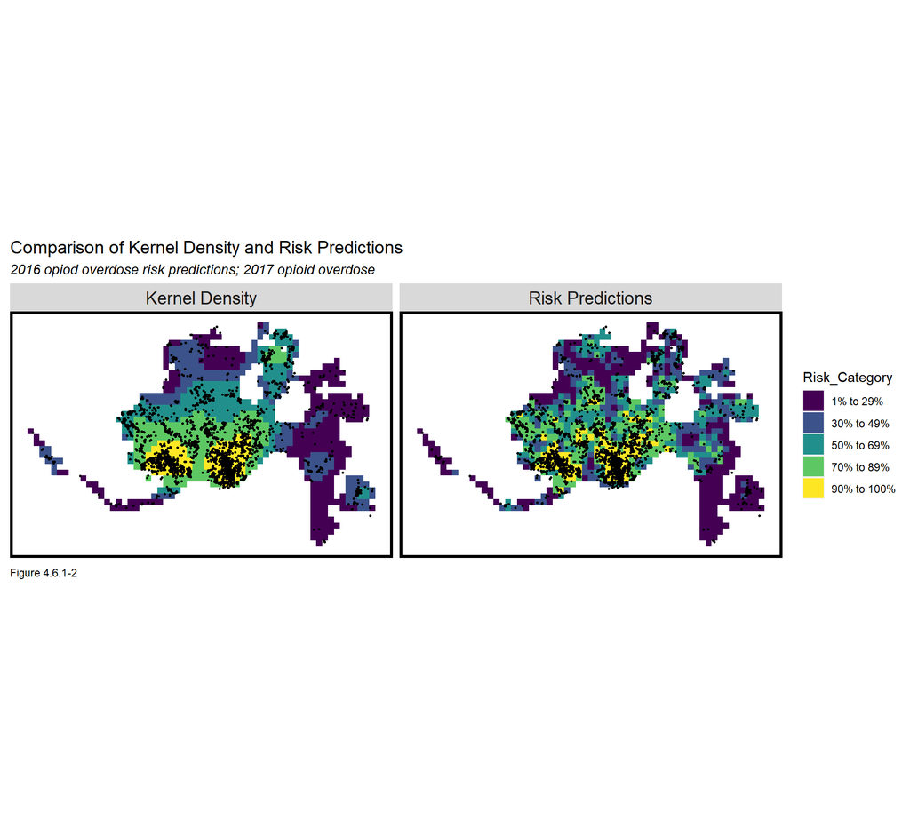

```r
burg_KDE_sf <- as.data.frame(burg_KD.1000) %>%
  st_as_sf(coords = c("x", "y"), crs = st_crs(cin_final_net)) %>%
  aggregate(., cin_final_net, mean) %>%
  mutate(label = "Kernel Density",
         Risk_Category = ntile(value, 100),
         Risk_Category = case_when(
           Risk_Category >= 90 ~ "90% to 100%",
           Risk_Category >= 70 & Risk_Category <= 89 ~ "70% to 89%",
           Risk_Category >= 50 & Risk_Category <= 69 ~ "50% to 69%",
           Risk_Category >= 30 & Risk_Category <= 49 ~ "30% to 49%",
           Risk_Category >= 1 & Risk_Category  <= 29 ~ "1% to 29%")) %>%
  cbind(
    aggregate(
      dplyr::select(opioid17) %>% mutate(opioidCount = 1), ., sum) %>%
    mutate(opioidCount = replace_na(opioidCount, 0))) %>%
  dplyr::select(label, Risk_Category, opioidCount)

###Prediction by Risk Prediction Model
burg_risk_sf <-
  reg.ss.spatialCV %>%
  mutate(label = "Risk Predictions",
         Risk_Category = ntile(Prediction, 100),
         Risk_Category = case_when(
         Risk_Category >= 90 ~ "90% to 100%",
         Risk_Category >= 70 & Risk_Category <= 89 ~ "70% to 89%",
         Risk_Category >= 50 & Risk_Category <= 69 ~ "50% to 69%",
         Risk_Category >= 30 & Risk_Category <= 49 ~ "30% to 49%",
         Risk_Category >= 1 & Risk_Category <= 29 ~ "1% to 29%")) %>%
  cbind(
    aggregate(
      dplyr::select(opioid17) %>% mutate(opioidCount = 1), ., sum) %>%
      mutate(opioidCount = replace_na(opioidCount, 0))) %>%
  dplyr::select(label,Risk_Category, opioidCount)

rbind(burg_KDE_sf, burg_risk_sf) %>%
  na.omit() %>%
  gather(Variable, Value, -label, -Risk_Category, -geometry) %>%
  ggplot() +
    geom_sf(aes(fill = Risk_Category), colour = NA) +
    geom_sf(data = sample_n(opioid17, 2500), size = .5, colour = "black") +
    facet_wrap(~label, ) +
    scale_fill_viridis(discrete = TRUE) +
    labs(title="Comparison of Kernel Density and Risk Predictions",
         subtitle="2016 opiod overdose risk predictions; 2017 opioid overdose",
         caption = "Figure 4.6.1-2") +
    mapTheme(title_size = 14)
```

#### 4.6.2 The bar plot making this comparison – Model Performance.

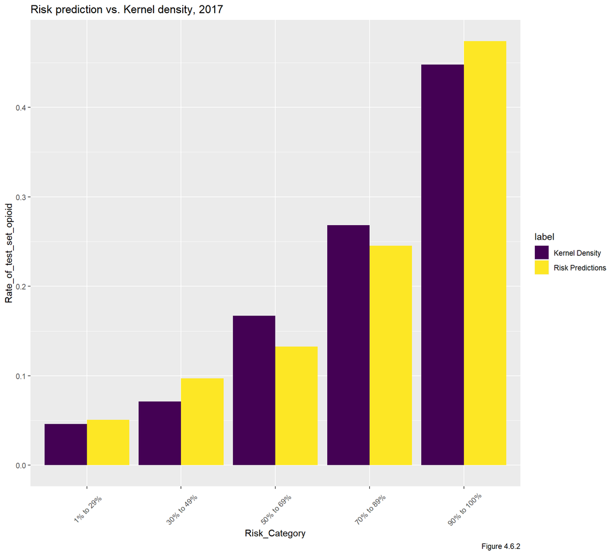

```r
rbind(burg_KDE_sf, burg_risk_sf) %>%
  st_set_geometry(NULL) %>% na.omit() %>%
  gather(Variable, Value, -label, -Risk_Category) %>%
  group_by(label, Risk_Category) %>%
  summarize(countopioid = sum(Value)) %>%
  ungroup() %>%
  group_by(label) %>%
  mutate(Rate_of_test_set_opioid = countopioid / sum(countopioid)) %>%
    ggplot(aes(Risk_Category,Rate_of_test_set_opioid)) +
      geom_bar(aes(fill=label), position="dodge", stat="identity") +
      scale_fill_viridis(discrete = TRUE) +
      labs(title = "Risk prediction vs. Kernel density, 2017",
      caption = "Figure 4.6.2")+
      theme(axis.text.x = element_text(angle = 45, vjust = 0.5))
```

#### 4.6.3 Example Map of Use Case

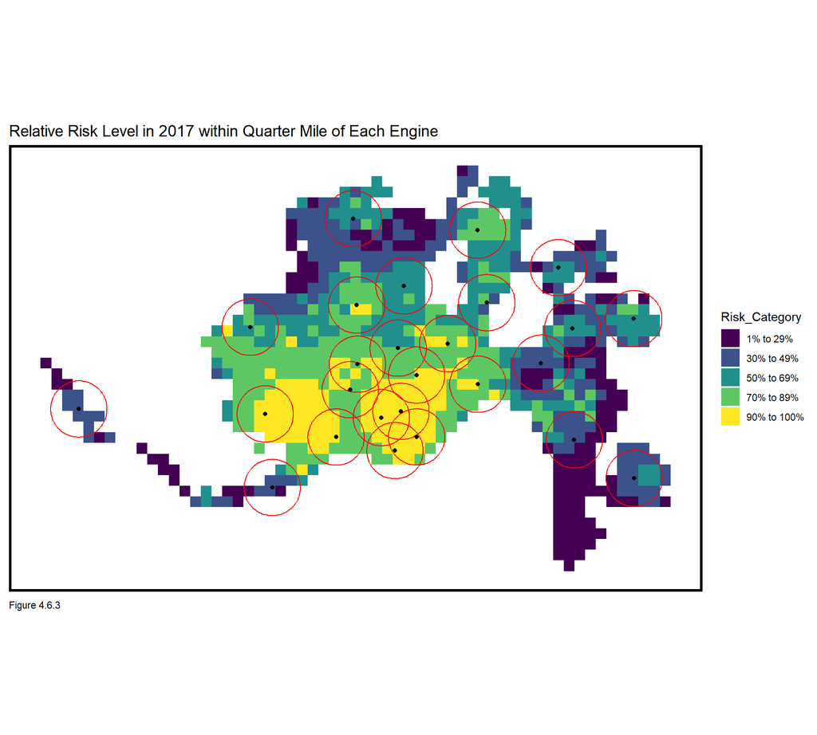

[figure not shown]

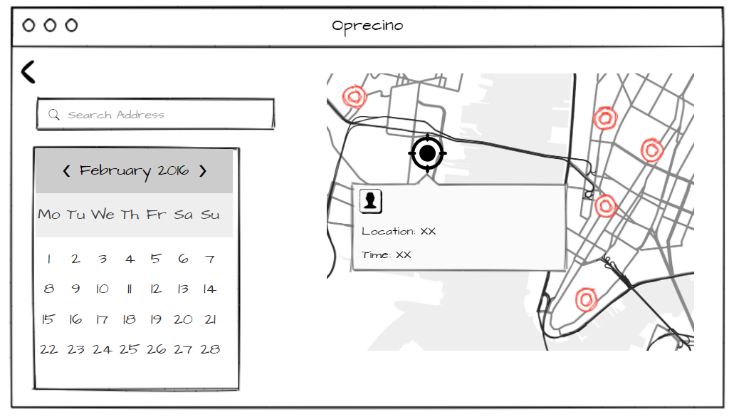

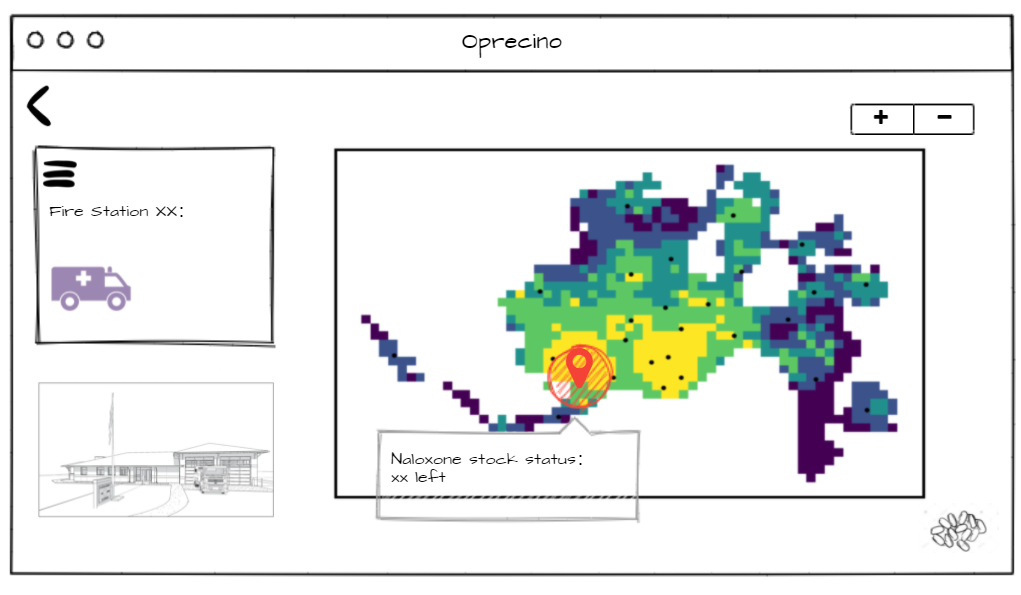

```r
rbind(burg_KDE_sf, burg_risk_sf) %>%
  na.omit() %>%
  gather(Variable, Value, -label, -Risk_Category, -geometry) %>%
  ggplot() +
  geom_sf(aes(fill = Risk_Category), colour = NA) +
  geom_sf(data = stationsBuffer_QtrMi, color = "red",fill="transparent") +
  geom_sf(data = firestation, aes(),fill ="black")+
  scale_fill_viridis(discrete = TRUE) +
  labs(title="Relative Risk Level in 2017 within Quarter Mile of Each Engine",
       caption = "Figure 4.6.3") +
  mapTheme(title_size = 14)
```

## IV. Conclusion

Generally speaking, this model achieves the goal of identifying opioid overdose risk hotspots in Cincinnati since it predicts hotspots more accurately than the traditional - Kernel Density model. We want to build a Web application that Cincinnati Fire Department stakeholders could use to understand the risks in an area and which facilities are best suited to respond (with adequate supply of the opioid antidote naloxone). The above figure roughly satisfies the use case we proposed at the beginning,that is which area should be allocated more resources. It shows the final risk prediction map, which the app envisages allowing the user to check the average predicted level around a selected fire station.Officials can better allocate resources, whether more specialists or emergency medicine are needed, depending on the situation at each station.In our initial vision for the wireframe, you can search for an address directly and the overdose events that has been reported nearby will be displayed. Or you can directly select a certain fire station, and the hot spots of overdose events within a quarter of a mile around it will be distinguished by different colors.If you click on the firehouse, a pop-up shows the status of the Naloxone reserve within the firehouse. This will give officials information on whether they need additional resources in this fire station. The accuracy of the data is reduced because they are anonymous and some unreported cases. For future work, the model can be improved by including more data and also using the other year data to do validation .